# MArine LItter Analysis Manual (ver beta)

2019/07/04

####Authors: ####*Tomoki Yasuhara* ####*Hiroaki Murata* ####*Toshihide Kitakado*

#2. Prerequisite ##2.1 Installation of packages ####If the follwing pacakges have not been installed, please execute next commented lines first.

```r
#install.packages("devtools")
#install.packages("dplyr")
library(devtools)
library(dplyr) #data handling

#install_github("y-yasutomo/malia")
#calling package in order to analyze marine debris data
library(malia0)
```

#3. See Data and set up of estimation ##3.1 Data visualization ####Survey track line

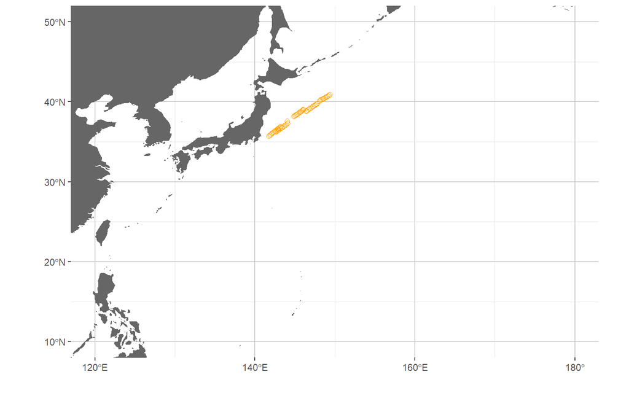

```r
#Designate voyage name
Vname<-"O18y1"
survey.plot(read.csv(paste(Vname,".effort.csv",sep="")))
```

##3.2 Set up of estimation ####Simple estimation using MALIA function ####Reading data

```r
Sight.Data<-read.csv(paste(Vname,".debris.csv",sep=""))
Effort.Data<-read.csv(paste(Vname,".effort.csv",sep=""))
```

##3.3 Estimation ####We shall estimate density of ‘EPS’ by ‘MALIA’ function

```r
tmp.Data<-Sight.Data %>%filter(type == "EPS")
res<-MALIA(tmp.Data,Effort.Data,key="hn",td=200)
```

```
Start from 789.711634597682
ite 1 value = 638.886473193106
ite 2 value = 638.886473193106
generated initial value!
```

####Densities in each leg

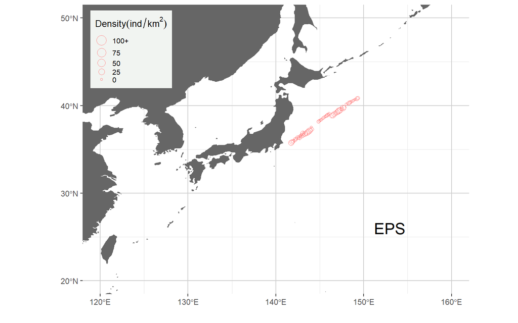

```r
leg.D.plot(res$leg.D.obs$leg.result,xl=c(120,160),yl=c(20,50),save=F,Type="EPS")
```

##3.4 Using full data ####SDAM function can conduct whole analysis ####i.e) estimate detection function, calculate densities in each debris type, covariate and detection function ####As it takes some time to finish all trials, we use already created results for mapping, model selection and making table.

```r
#res<-SDAM(Voyage.name=Vname,COVARIATE = c("conv", "occo","weather", "size"), key.list = c("hn","hr", "hhn", "hhr"),td=200,cp=10)
#Reading result object
res<-readRDS(paste(Vname,".result.obj",sep=""))
```

#4. Result handling ##4.1 Drawing maps ####Maps with trackline and estimated density

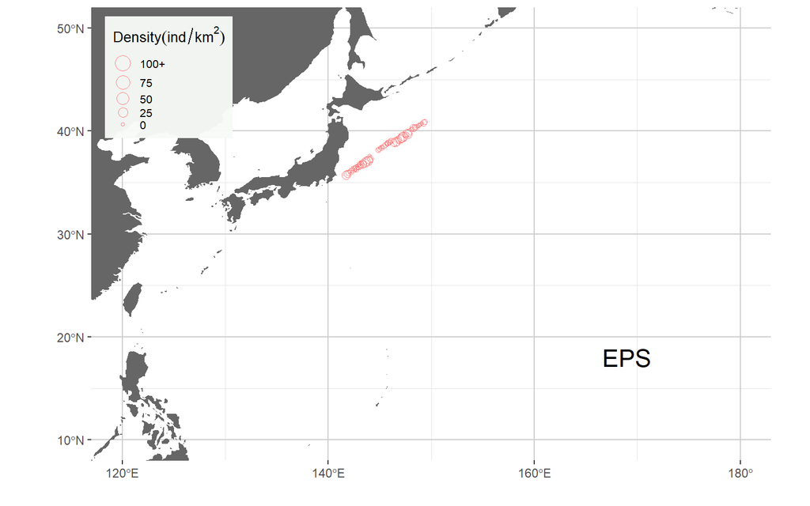

```r
#let's see type 'EPS'
leg.D.res<-res$hhr$weather$EPS$leg.D.obs$leg.result
leg.D.plot(leg.D.res,save=F,Type='EPS')
```

####Density of “EPS” by grid

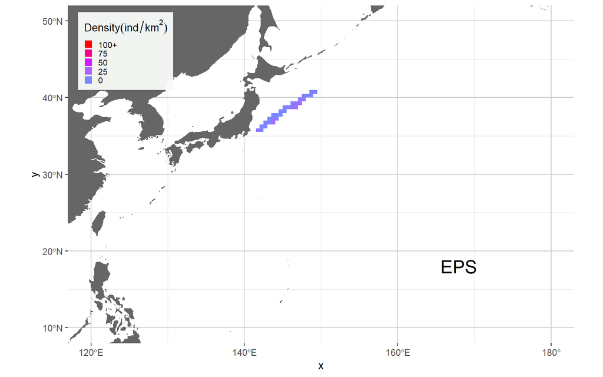

```r
 grid.D.res<-res$hhr$weather$EPS$grid.D.res
 grid.D.plot(grid.D.res,save=F,Type='EPS')
```

##4.2 Model selection ####model summary

```r
 aic.mat<-aic.summary(res)
 aic.mat$EPS
```

| Key | Covariate | AIC |
| --- | --- | --- |
| hn | conv | 1277.769 |
| hr | conv | 3394.093 |
| hhn | conv | 1291.816 |
| hhr | conv | 2444.953 |
| hn | occo | 1665.684 |
| hr | occo | 1211.122 |
| hhn | occo | 1254.887 |
| hhr | occo | 1148.979 |
| hn | weather | 1266.095 |
| hr | weather | 1216.888 |

[output cut: 6 more lines]

####model.extract function can extract best models in each debris type easily from SDAM result

```r
 best.model<-model.extract(aic.mat,res)
 best.model$best.mat
```

|  | Key | Covariate | AIC |
| --- | --- | --- | --- |
| DW | hhr | weather | 651.510514 |
| EPS | hhr | occo | 1148.979327 |
| FGF | hhr | conv | 75.470455 |
| FGN | hhn | size | 47.266631 |
| FGO | hr | size | 36.766292 |
| FP | hhr | conv | 171.723667 |
| G | hn | conv | 6.861077 |
| M | hhn | weather | 76.033831 |
| NO | hhr | size | 848.659985 |
| PBA | hhr | size | 513.600085 |

[output cut: 6 more lines]

##4.3 Creating table ####Summary of densities by leg

```r
 leg.table<-leg.D.table(best.model$best.list)
 head(leg.table)
```

|  | Voyage_name | Leg.No. | Leg.Length | DW_Density | DW_Abundance | DW_Detected.Number | EPS_Density | EPS_Abundance | EPS_Detected.Number | FGF_Density | FGF_Abundance | FGF_Detected.Number | FGN_Density | FGN_Abundance | FGN_Detected.Number | FGO_Density | FGO_Abundance | FGO_Detected.Number | FP_Density | FP_Abundance | FP_Detected.Number | G_Density | G_Abundance | G_Detected.Number | M_Density | M_Abundance | M_Detected.Number | NO_Density | NO_Abundance | … |
| --- | --- | --- | --- | --- | --- | --- | --- | --- | --- | --- | --- | --- | --- | --- | --- | --- | --- | --- | --- | --- | --- | --- | --- | --- | --- | --- | --- | --- | --- | --- |
| 1 | O18y1 | 1 | 18.902062 | 4.111245 | 77.71101 | 1 | 16.816340 | 317.86350 | 17 | 0.5702303 | 10.77853 | 1 | 0.000000 | 0.00000 | 0 | 0 | 0 | 0 | 0.000000 | 0.00000 | 0 | 0 | 0 | 0 | 6.320801 | 119.4762 | 1 | 1.237268 | 23.38691 | … |
| 2 | O18y1 | 2 | 9.823665 | 0.000000 | 0.00000 | 0 | 7.613392 | 74.79141 | 4 | 1.0972003 | 10.77853 | 1 | 10.136788 | 99.58041 | 1 | 0 | 0 | 0 | 0.000000 | 0.00000 | 0 | 0 | 0 | 0 | 0.000000 | 0.0000 | 0 | 0.000000 | 0.00000 | … |
| 3 | O18y1 | 3 | 18.586601 | 12.423614 | 230.91275 | 4 | 3.454348 | 64.20460 | 3 | 0.0000000 | 0.00000 | 0 | 1.324859 | 24.62462 | 1 | 0 | 0 | 0 | 2.445608 | 45.45554 | 1 | 0 | 0 | 0 | 0.000000 | 0.0000 | 0 | 0.000000 | 0.00000 | … |
| 4 | O18y1 | 4 | 9.038264 | 0.000000 | 0.00000 | 0 | 0.000000 | 0.00000 | 0 | 0.0000000 | 0.00000 | 0 | 0.000000 | 0.00000 | 0 | 0 | 0 | 0 | 0.000000 | 0.00000 | 0 | 0 | 0 | 0 | 0.000000 | 0.0000 | 0 | 0.000000 | 0.00000 | … |
| 5 | O18y1 | 5 | 18.423266 | 0.000000 | 0.00000 | 0 | 5.074522 | 93.48927 | 5 | 0.0000000 | 0.00000 | 0 | 0.000000 | 0.00000 | 0 | 0 | 0 | 0 | 0.000000 | 0.00000 | 0 | 0 | 0 | 0 | 0.000000 | 0.0000 | 0 | 4.679135 | 86.20494 | … |
| 6 | O18y1 | 6 | 9.174922 | 0.000000 | 0.00000 | 0 | 2.037931 | 18.69785 | 1 | 0.0000000 | 0.00000 | 0 | 0.000000 | 0.00000 | 0 | 0 | 0 | 0 | 0.000000 | 0.00000 | 0 | 0 | 0 | 0 | 0.000000 | 0.0000 | 0 | 3.712932 | 34.06587 | … |

```r
 #write.xlsx(leg.table,file=paste(table.pass,"leg.D.table.xlsx",sep=""),row.names=F)
```

####Summary of densities by grid

```r
 grid.table<-grid.D.table(best.model$best.list)
 head(grid.table)
```

|  | Voyage_name | lat.min | lat.max | lon.min | lon.max | Total.length | DW_Density | EPS_Density | FGF_Density | FGN_Density | FGO_Density | FP_Density | G_Density | M_Density | NO_Density | PBA_Density | PBO_Density | PC_Density | SW_Density | UK_Density | UO_Density | W_Density |
| --- | --- | --- | --- | --- | --- | --- | --- | --- | --- | --- | --- | --- | --- | --- | --- | --- | --- | --- | --- | --- | --- | --- |
| 14 | O18y1 | 35.5 | 36.0 | 141.5 | 142.0 | 42.658119 | 5.8793415 | 10.332905 | 0.50534480 | 2.7670900 | 0.000000 | 0.7987498 | 0 | 2.8007842 | 0.5482406 | 3.6348463 | 6.3617901 | 13.515534 | 13.983538 | 0.000000 | 5.730631 | 1.5400363 |
| 26 | O18y1 | 35.5 | 36.0 | 142.0 | 142.5 | 6.396301 | 9.0399166 | 2.513522 | 0.00000000 | 0.9640199 | 0.000000 | 1.7795218 | 0 | 0.0000000 | 0.0000000 | 2.2076784 | 0.0000000 | 17.753716 | 29.076289 | 0.000000 | 0.000000 | 0.0000000 |
| 27 | O18y1 | 36.0 | 36.5 | 142.0 | 142.5 | 57.057558 | 0.8387192 | 2.277147 | 0.00000000 | 0.0000000 | 0.000000 | 0.7966613 | 0 | 0.0000000 | 2.5177683 | 0.0000000 | 1.4814525 | 3.533654 | 43.258096 | 0.000000 | 1.398079 | 0.0000000 |
| 39 | O18y1 | 36.0 | 36.5 | 142.5 | 143.0 | 59.763436 | 2.4715164 | 2.367067 | 0.17270177 | 0.7806773 | 1.676246 | 2.5902512 | 0 | 0.3789837 | 1.3516362 | 5.5680323 | 0.3694174 | 10.353659 | 25.557563 | 2.325975 | 2.212597 | 1.0300547 |
| 40 | O18y1 | 36.5 | 37.0 | 142.5 | 143.0 | 39.921436 | 3.4314239 | 0.368936 | 0.01147523 | 0.5722145 | 0.000000 | 0.7835975 | 0 | 0.0000000 | 0.9907112 | 0.5014196 | 0.4299891 | 6.444732 | 15.396038 | 0.000000 | 3.609365 | 2.4006094 |
| 52 | O18y1 | 36.5 | 37.0 | 143.0 | 143.5 | 96.789138 | 9.1723056 | 5.381490 | 0.00000000 | 3.8762963 | 0.000000 | 4.6523307 | 0 | 0.0000000 | 11.5076778 | 4.7448699 | 0.9168166 | 7.404028 | 6.926795 | 2.231673 | 2.661499 | 0.4100859 |

```r
 #write.xlsx(grid.table,file=paste(table.pass,"grid.D.table.xlsx",sep=""),row.names=F)
```

####Summary of densities by area

```r
 area.table<-area.D.table(best.model$best.list)
 head(area.table)
```

|  | Voyage_name | Area | Total.Length | DW_Density | EPS_Density | FGF_Density | FGN_Density | FGO_Density | FP_Density | G_Density | M_Density | NO_Density | PBA_Density | PBO_Density | PC_Density | SW_Density | UK_Density | UO_Density | W_Density |
| --- | --- | --- | --- | --- | --- | --- | --- | --- | --- | --- | --- | --- | --- | --- | --- | --- | --- | --- | --- |
| 1 | O18y1 | 1 | 0 | NaN | NaN | NaN | NaN | NaN | NaN | NaN | NaN | NaN | NaN | NaN | NaN | NaN | NaN | NaN | NaN |
| 2 | O18y1 | 2 | 0 | NaN | NaN | NaN | NaN | NaN | NaN | NaN | NaN | NaN | NaN | NaN | NaN | NaN | NaN | NaN | NaN |
| 3 | O18y1 | 3 | 0 | NaN | NaN | NaN | NaN | NaN | NaN | NaN | NaN | NaN | NaN | NaN | NaN | NaN | NaN | NaN | NaN |
| 4 | O18y1 | 4 | 0 | NaN | NaN | NaN | NaN | NaN | NaN | NaN | NaN | NaN | NaN | NaN | NaN | NaN | NaN | NaN | NaN |
| 5 | O18y1 | 5 | 0 | NaN | NaN | NaN | NaN | NaN | NaN | NaN | NaN | NaN | NaN | NaN | NaN | NaN | NaN | NaN | NaN |
| 6 | O18y1 | 6 | 0 | NaN | NaN | NaN | NaN | NaN | NaN | NaN | NaN | NaN | NaN | NaN | NaN | NaN | NaN | NaN | NaN |

```r
 #write.xlsx(area.table,file=paste(table.pass,"area.D.table.xlsx",sep=""),row.names=F)
```

#5. Ar and Nt products ##5.1. Classify each debris into categories ####ls. function can sum up artificial and natural products

```r
 Ar<-c("FGN","FGF","FGO","EPS","PBA","PBO","FP","PC","G","M","W","UO")
 Nt<-c("SW","DW","NO")
 An.table<-ls.(leg.table,Voyage.name,Ar,Nt)
 head(An.table)
```

|  | Leg.No. | Leg.Length | Lat.Start | Lon.Start | Lat.End | Lon.End | Voyage_name | Artificial_Number | Artificial_Density | Natural_Number | Natural_Density |
| --- | --- | --- | --- | --- | --- | --- | --- | --- | --- | --- | --- |
| 1 | 1 | 18.902062 | 35.68841 | 141.6653 | 35.80892 | 141.8130 | O18y1 | 42 | 60.90233 | 4 | 10.68399 |
| 2 | 2 | 9.823665 | 35.80892 | 141.8130 | 35.87148 | 141.8899 | O18y1 | 15 | 48.48070 | 5 | 19.85985 |
| 3 | 3 | 18.586601 | 35.87148 | 141.8899 | 35.98891 | 142.0368 | O18y1 | 17 | 30.11885 | 13 | 33.99661 |
| 4 | 4 | 9.038264 | 35.98891 | 142.0368 | 36.04769 | 142.1062 | O18y1 | 3 | 12.12651 | 9 | 49.12217 |
| 5 | 5 | 18.423266 | 36.04769 | 142.1062 | 36.16471 | 142.2514 | O18y1 | 7 | 7.37107 | 17 | 47.62894 |
| 6 | 6 | 9.174922 | 36.16471 | 142.2514 | 36.22143 | 142.3256 | O18y1 | 3 | 10.69208 | 17 | 90.80294 |

####Plot of Artificial product

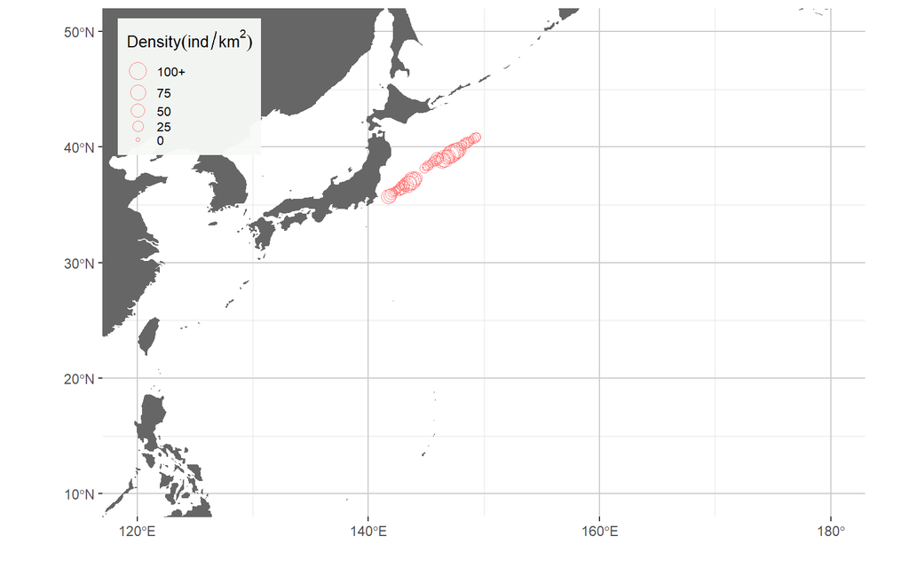

```r
 Artificial.leg<-An.table %>%  select(Leg.No.,Leg.Length,Lat.Start,Lon.Start,Lat.End,Lon.End,Artificial_Density) %>% rename(Density=Artificial_Density)
 leg.D.plot(Artificial.leg,save=F)
```

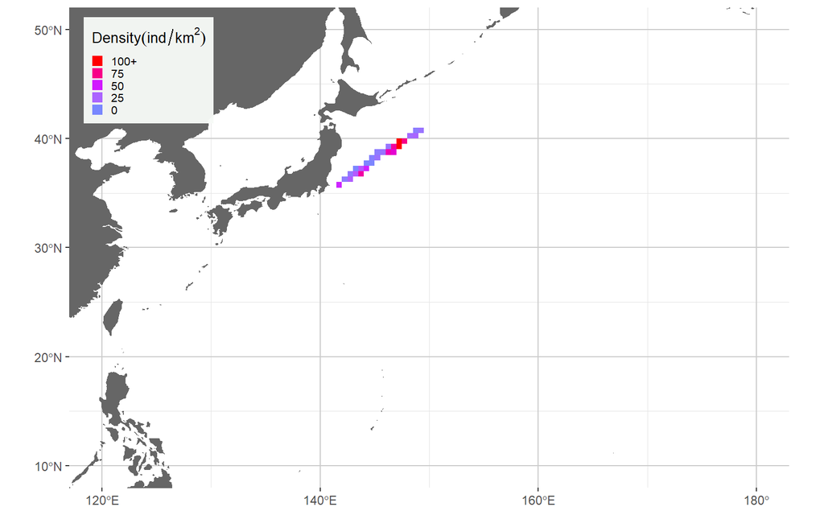

```r
 Artificial.grid<-grid.D(Artificial.leg)
 grid.D.plot(Artificial.grid,save = F)
```

####Plot of Natural product

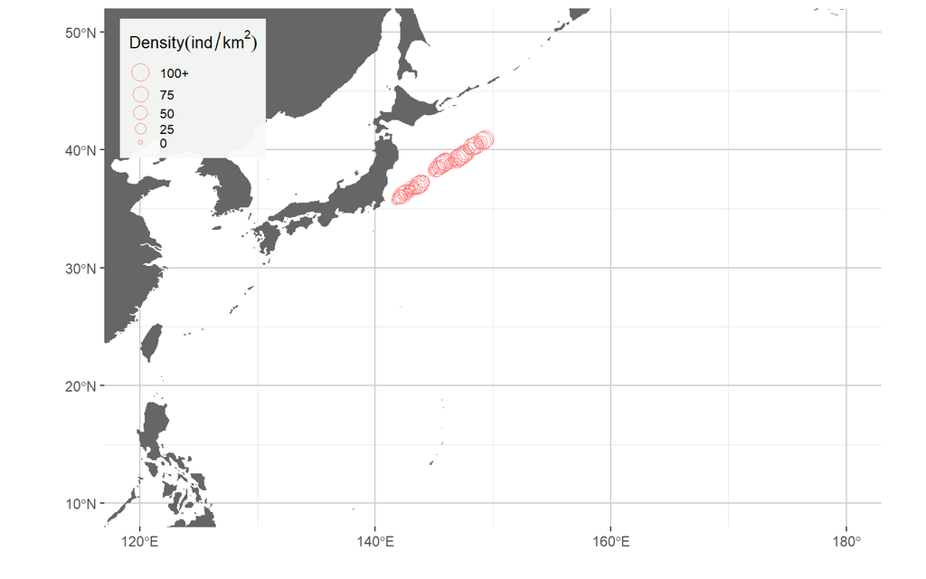

```r
Natural.leg<-An.table %>%  select(Leg.No.,Leg.Length,Lat.Start,Lon.Start,Lat.End,Lon.End,Natural_Density) %>% rename(Density=Natural_Density)
 leg.D.plot(Natural.leg,save=F)
```

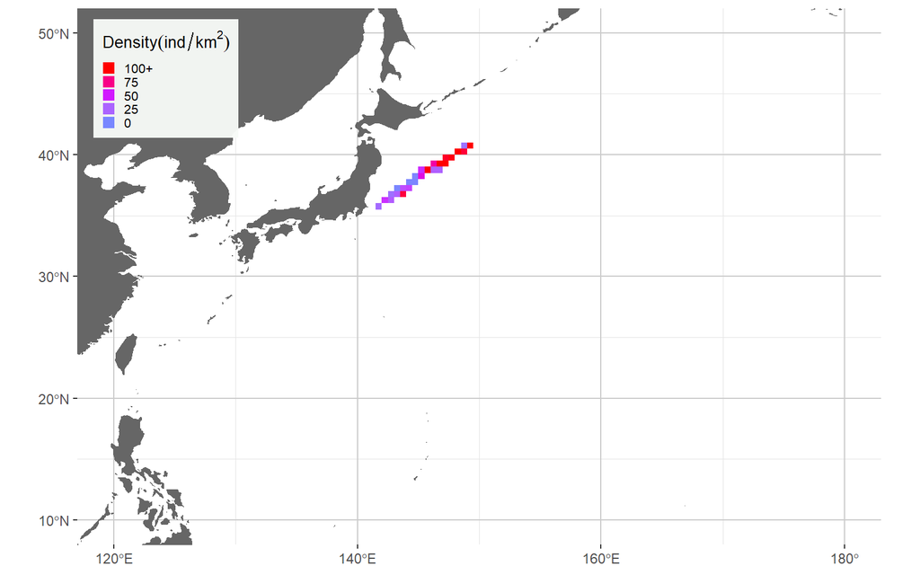

```r
 Natural.grid<-grid.D(Natural.leg)
 grid.D.plot(Natural.grid,save = F)
```

##5.2. Combining results ####Combining results across multiple surveys. In this procedure, it is necessary result objects has to already be created. ####Survey legs

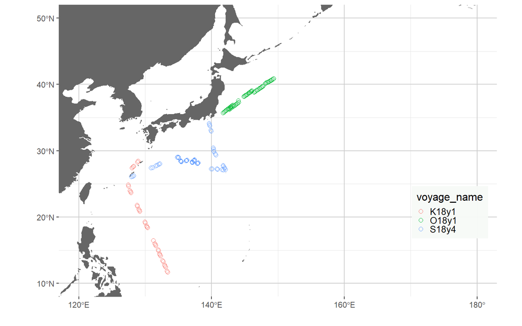

```r
 vname<-c("S18y4","O18y1","K18y1")
 tmp<-data.frame()
for(i in 1:length(vname)){
  Effort.Data<-read.csv(paste(vname[i],".effort.csv",sep=""))
  Effort.Data$voyage_name<-vname[i]
  tmp<-rbind(tmp,Effort.Data)
}
 survey.plot(tmp,multi=T)
```

####Combine leg D results ####In the leg.D.comb function, model selection and extraction of the best model are conducted.

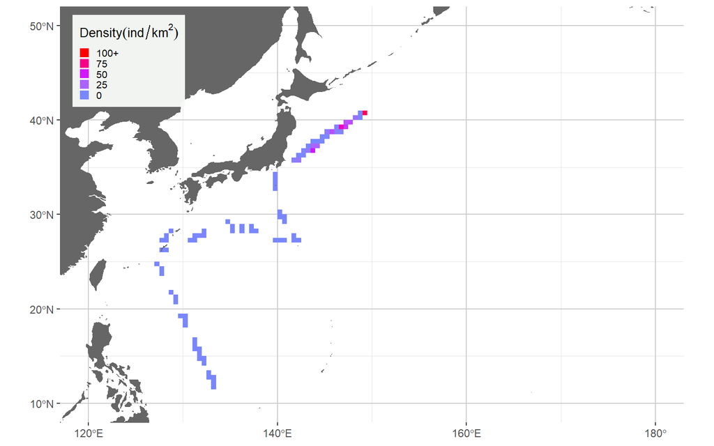

```r
 tmp<-leg.D.comb(vname)
#let's see type "DW"
 tmp2<-grid.D(tmp$DW)
 grid.D.plot(tmp2,save = F)
```

```r
#area D
 tmp3<-area.D(tmp$DW)
 tmp3$area.density
```

| Area | Density | Total.Length |
| --- | --- | --- |
| 1 | NaN | 0.0000 |
| 2 | NaN | 0.0000 |
| 3 | NaN | 0.0000 |
| 4 | NaN | 0.0000 |
| 5 | NaN | 0.0000 |
| 6 | NaN | 0.0000 |
| 7 | 18.7962061 | 1034.6821 |
| 8 | NaN | 0.0000 |
| 9 | NaN | 0.0000 |
| 10 | 0.0000000 | 100.6888 |

[output cut: 7 more lines]

####Artificial and Natural products ####Artificial product

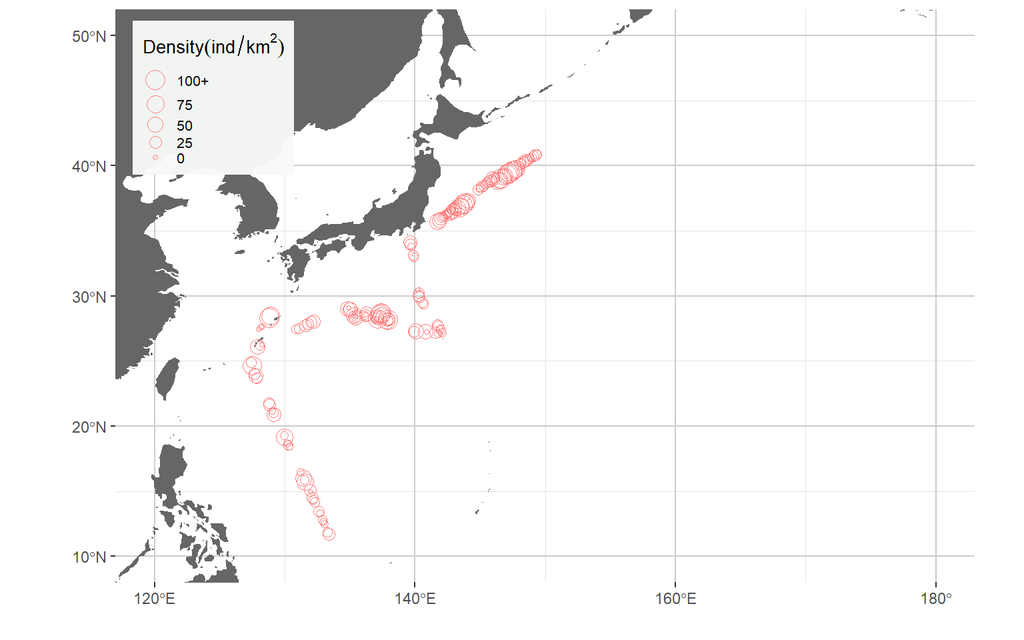

```r
 tmp<-vanc(vname)
 leg.D.plot(tmp$Ar.leg.D,save=F)
```

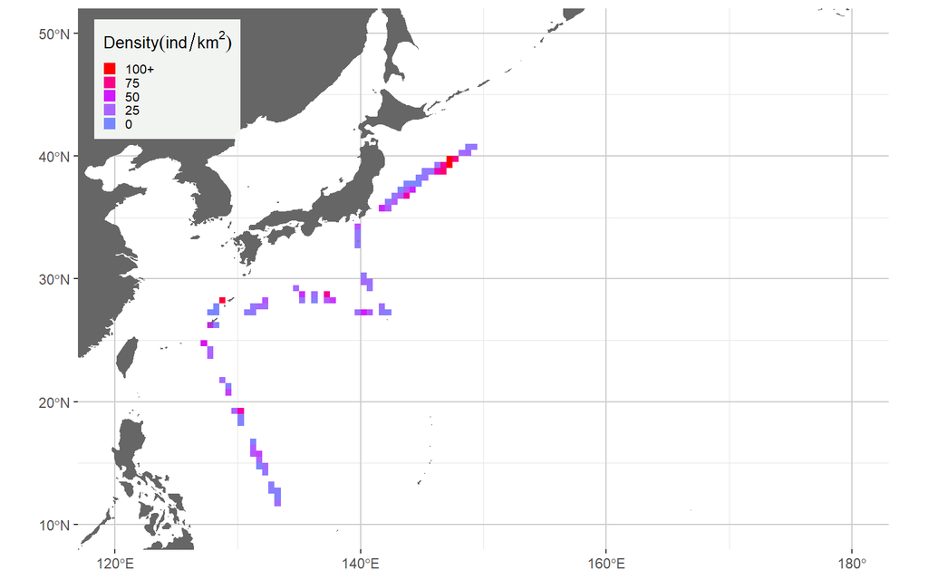

```r
 Artificial.grid<-grid.D(tmp$Ar.leg.D)
 grid.D.plot(Artificial.grid,save = F)
```

####Natural product

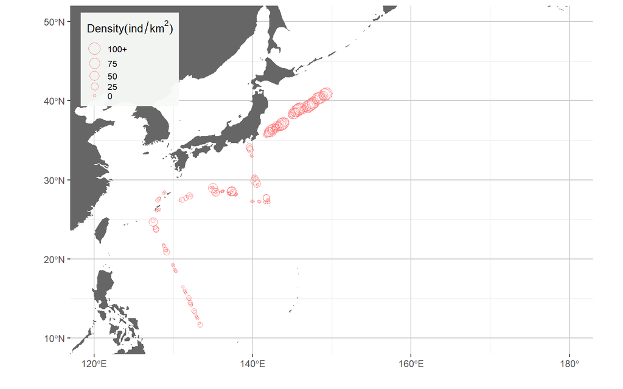

```r
 leg.D.plot(tmp$Nt.leg.D,save=F)
```

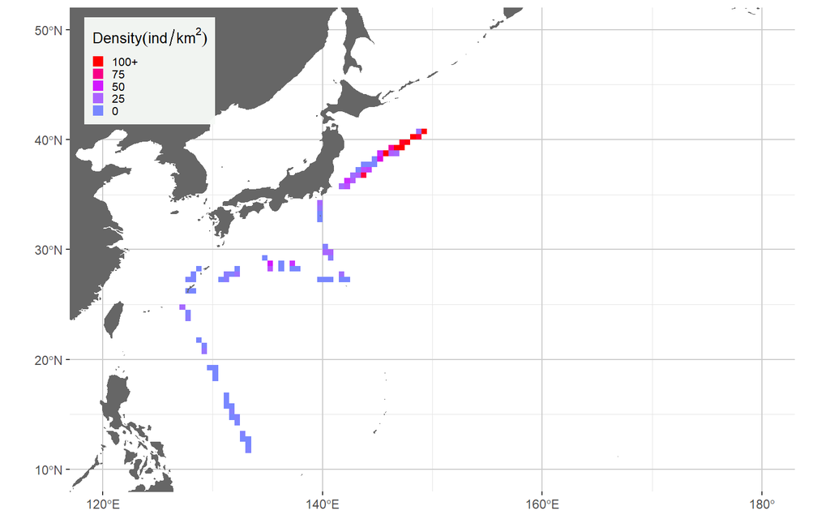

```r
 Natural.grid<-grid.D(tmp$Nt.leg.D)
 grid.D.plot(Natural.grid,save = F)
```